# JELSCH BOND 2_0_0.15_10_Density

## Sample=1ejg-a:9:c-a:10:n-a:9:o

| pdb_code | central atom | ca density | parallel atom | pa density | planar atom | pl density |
| --- | --- | --- | --- | --- | --- | --- |
| 1ejg | [6.5, 5.51, 9.74] | 388.3102 | [7.68, 4.9, 9.9] | 553.3651 | [6.09, 5.89, 8.64] | 602.2972 |

## 3d view of density

xyz

yzx

zxy

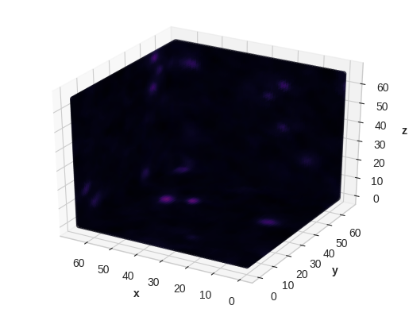

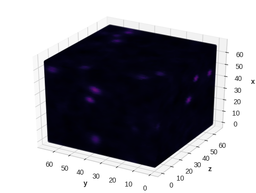

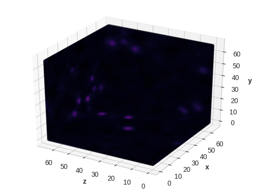

## Histograms of densities

Matrix Histogram

Entire Density Histogram

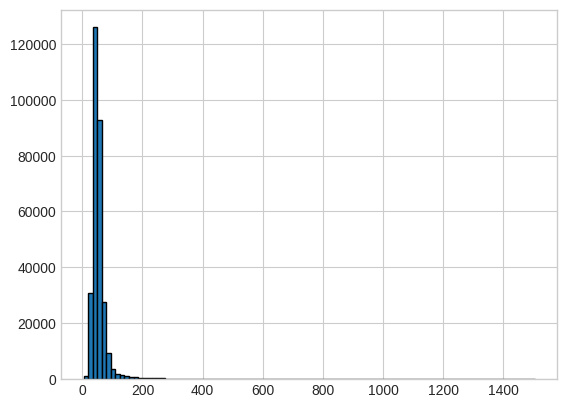

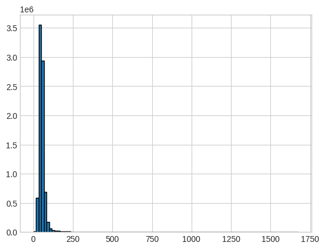

## Slices along x,y and z

Sliced x-wise

Sliced y-wise

Sliced z-wise

0/67

0/67

0/67

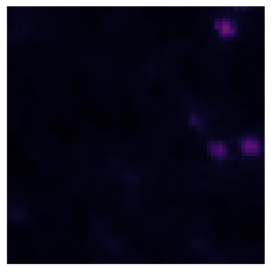

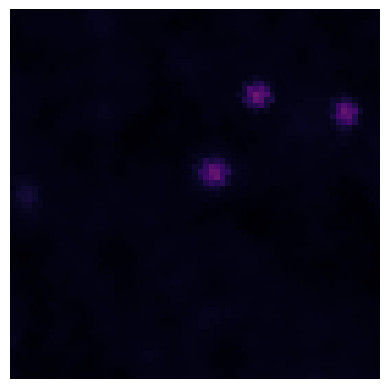

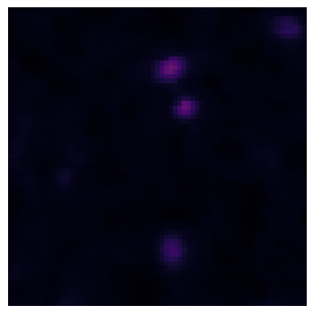

1/67

1/67

1/67

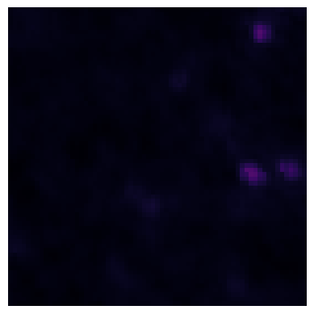

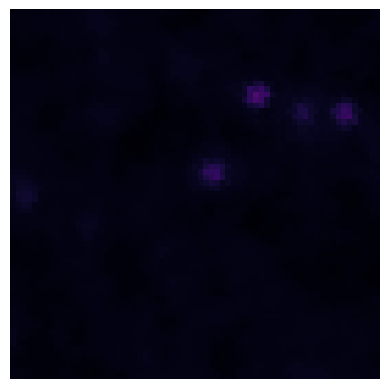

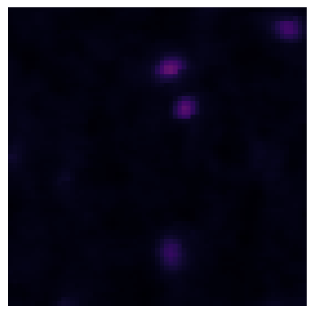

2/67

2/67

2/67

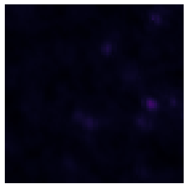

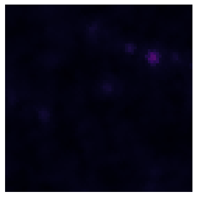

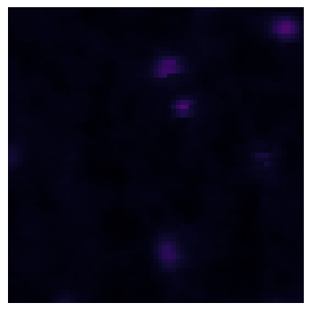

3/67

3/67

3/67

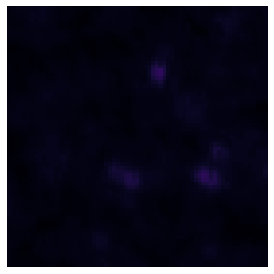

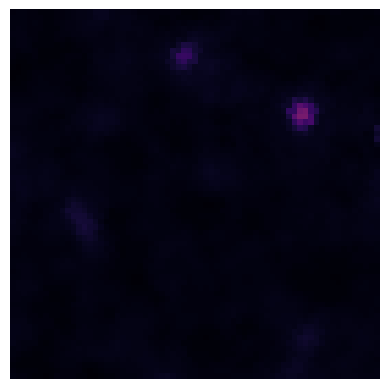

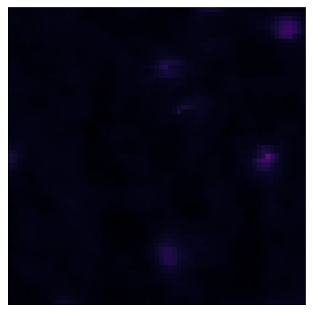

4/67

4/67

4/67

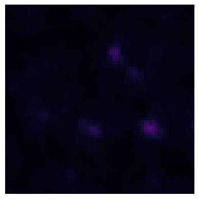

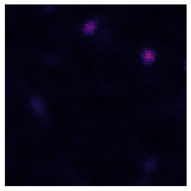

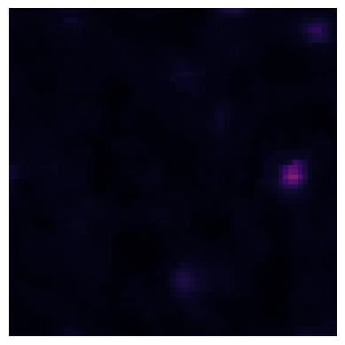

5/67

5/67

5/67

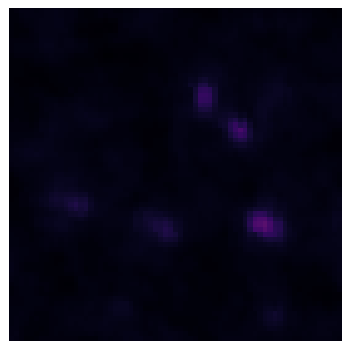

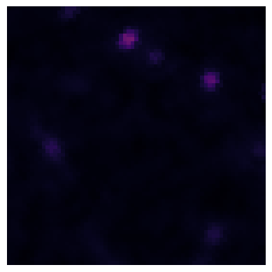

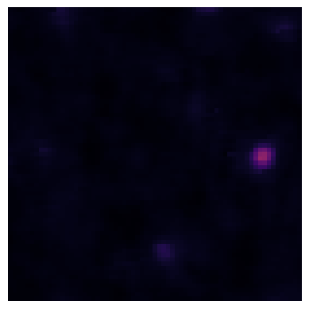

6/67

6/67

6/67

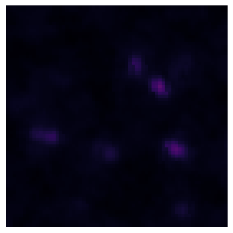

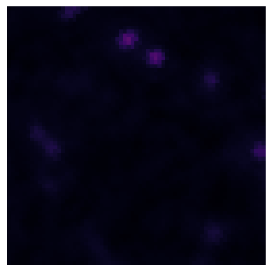

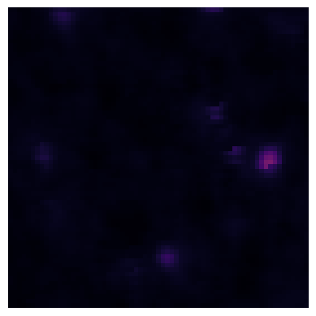

7/67

7/67